# ACL data

### Note

This was generated from patients whose 1RM test scores were entered in { }s in Citrix.

Patients whose IC started with S70xxx and S80xxx were excluded.

### Data extracted

|  | operation.start.date | authored.date | datediff | inv_knee_ext | uninv_knee_ext | percentage_knee_ext |
| --- | --- | --- | --- | --- | --- | --- |
| 1 | 2019-12-11 | 2020-02-27 | 11.14 | 75 | 110 | 68.18 |
| 2 | 2019-10-17 | 2019-12-27 | 10.14 | 100 | 160 | 62.5 |
| 3 | 2019-10-17 | 2020-01-22 | 13.86 | 140 | 190 | 73.68 |
| 4 | 2019-10-18 | 2019-12-27 | 10 | 60 | 110 | 54.55 |
| 5 | 2019-11-11 | 2020-01-29 | 11.29 | 80 | 100 | 80 |
| 6 | 2019-12-23 | 2020-03-09 | 11 | 25 | 80 | 31.25 |
| 7 | 2019-12-23 | 2020-03-09 | 11 | 25 | 80 | 31.25 |
| 8 | 2019-10-24 | 2020-01-10 | 11.14 | 40 | 75 | 53.33 |
| 9 | 2019-12-19 | 2020-03-05 | 11 | 70 | 130 | 53.85 |
| 10 | 2019-08-31 | 2019-11-22 | 11.86 | 100 | 130 | 76.92 |

[output cut: 18 more lines]

### Mean

Mean of knee extension test percentage

Only those tested between week 10 and week 14 were included in the calculation.

```
## [1] 70.69333
```

### Knee extension mean ratio

From Week 10-Week 14:

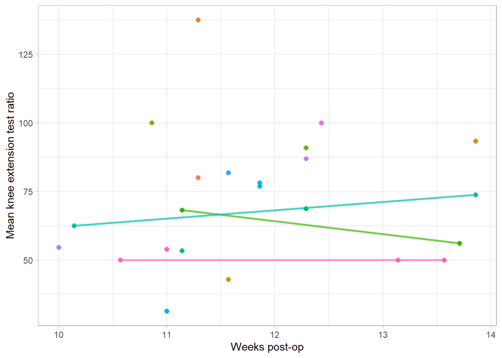

### Reminder

When entering 1RM test acronym expansion into Citrix:

1. Kindly remember to use the table with the { }s in P drive. There were some that used ( )s.
2. Do not modify the table.
3. Make sure date entered is accurate. Do not remove the { }s for the date in the table. (During extraction, all dates in the { }s that does not match with the date entered into Citrix will be excluded.)
4. Do not remove { }s. If the test was not done, leave the brackets with nothing in it.
5. Do not only copy rows of the table that were tested, copy the whole table onto Citrix. (i.e. if only ROM was tested, enter ROM and leave the rest of the { }s empty, but copy the whole table)
6. Reminder to enter data into the correct cells. There were a few wrong entries into the ROM { }s. Maybe change the layout if it is too confusing.

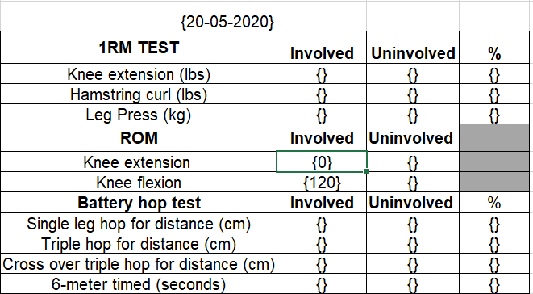

Example

### Suggestions

1. Remove hop test from the 1RM table. Maybe enter it as another table using double brackets {{ }}?
2. If possible, try to keep the table at the very top of the text box in Citrix. Other objective information can come after. (Only on documentation entered on the day of the test).
3. Maybe enter range as another table so that it can be entered and extracted from the first visit? This is a measure that is measured very often. Would it be useful information? This would also help the layout confusion.